# Gotta catch ’em all

[figure not shown]

## Data

[The dataset for this assignment can be found as a csv file at here](https://raw.githubusercontent.com/LF2L/reproducible-research/gh-pages/assets/data/pokemon.csv). Save the data as `Pokemon.csv`.

The variable descriptions are as follows:

- `name`: A unique name given to the Pokémon
- `species`: The Pokémon’s type, e.g. Pidgey.
- `cp`: Pre-evolution Combat Power, which is a summary of the Pokémon’s strength for battling prior to the evolution of the Pokémon.
- `hp`: Pre-evolution Hit Points, which is a summary of how difficult it is to weaken the Pokémon in a battle.
- `weight`: Pre-evolution weight, in kilograms.
- `height`: Pre-evolution height, in meters.
- `power_up_stardust`: Pre-evolution stardust required to power up the Pokémon.
- `power_up_candy`: Pre-evolution candy required to power up the Pokémon.
- `attack_weak`: The name of the pre-evolution weaker attack of the Pokémon.
- `attack_weak_type`: The type of the pre-evolution weaker attack.
- `attack_weak_value`: The damage done by the pre-evolution weaker attack.
- `attack_strong`: The name of the pre-evolution stronger attack.
- `attack_strong_type`: The type of the pre-evolution stronger attack.
- `attack_strong_value`: The damage done by the pre-evolution stronger attack.
- `cp_new`: Post-evolution Combat Power.
- `hp_new`: Post-evolution Hit Points.
- `weight_new`: Post-evolution weight, in kilograms.
- `height_new`: Post-evolution height, in meters.
- `power_up_stardust_new`: Post-evolution stardust required to power up the Pokémon.
- `power_up_candy_new`: Post-evolution candy required to power up the Pokémon.
- `attack_weak_new`: The name of the post-evolution weaker attack.
- `attack_weak_type_new`: The type of the post-evolution weaker attack.
- `attack_weak_value_new`: The damage done by the post-evolution weaker attack.
- `attack_strong_new`: The name of the post-evolution stronger attack.
- `attack_strong_type_new`: The type of the post-evolution stronger attack.
- `attack_strong_value_new`: The damage done by the post-evolution stronger attack.
- `notes`: Any additional notes made while collecting the data.

## Exercises

- First element to do in data analysis is to `setup` the libraries that we need

````markdown
```{r setup, include=FALSE}
knitr::opts_chunk$set(echo = TRUE)
library(tidyverse)

```
````

- Here the code for reading the data

````markdown
```{r Data, echo = FALSE}
Pokemon = read_csv("Pokemon.csv") # Reading the data
```
````

- Calculate the difference in heights pre and post evolution and save this as a new variable.
- Calculate the percentage of Pokémon that grew during evolution.
- Here are the mean values of weigth and heith Pre-evolution. What are the mean value of for Post-Evolution?

[output not shown]

- Also visualize the distribution of change in height by species and provide a discussion of how change in height varies across species. **Create an histogram)**
- Can you recreate the following plot?:

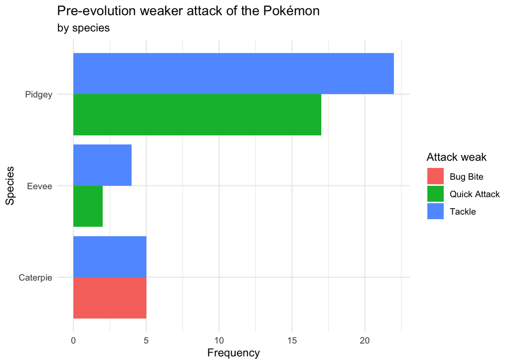

- Pick a numerical and a categorical variable, and construct side-by-side box plots depicting the relationship between them.

[figure not shown]

- Could you imagine another visualization?